# Ones and Zeros in a number

I was finally determined to put something onto GitHub. But, I was not sure what to do.

The other day, I was wondering how would it look if we tried to plot ones and zeros in binary representation of a given integer. Having taken up some training on matplotlib recently, I thouhgt I will try my hand at it.

To being with, let's import the necesary packages

- numpy for arange() function
- pandas for DataFrame
- matplotlib for pyplot
- seaborn to for heatmap and make our plots look a bit nicer!

I am using python 3.6

```python
import numpy as np
import pandas as pd
import matplotlib.pyplot as plt
import seaborn as sns

% matplotlib notebook
```

We can use bin() funtion to find the binary representation of an integer as a string. Here is an example:

```python
bin(6)
```

```
'0b110'
```

Let's define a function

- that takes an integer in decimal form
- ginds its binary string representation
- strips the '0b' from it
- counts number of '0' in the remaining string

```python
def zeros(n):
    count = 0
    for z in bin(n).split('0b')[1].split('1'):
        if z:
            count += len(z)

    return count
```

Let's define another function that does almost exactly same except it counts number of '1's in the binary string

```python
def ones(n):
    count = 0
    for z in bin(n).split('0b')[1].split('0'):
        if z:
            count += len(z)

    return count
```

Now, let's create a DataFrame whose first column contains integers from 0 to n (represented by variable 'end' in this case). We use np.arange(start, stop, step) function to generate these numbers.

```python
end = 16
df = pd.DataFrame(np.arange(0, end, 1), columns=['n'])
df.head()
```

|  | n |
| --- | --- |
| 0 | 0 |
| 1 | 1 |
| 2 | 2 |
| 3 | 3 |
| 4 | 4 |

Let's now find number of zeros in binary string for each of these numbers and put them into column 'zeros' of our dataframe

```python
df['zeros'] = list(map(zeros, df['n']))
```

## Line plot

It's time to plot them and see how they look.

- we first set seaborn plotting using sns.set() so the plot is drawn with seaborn styles
- use integers on x-axis and number of zeros on y-axis

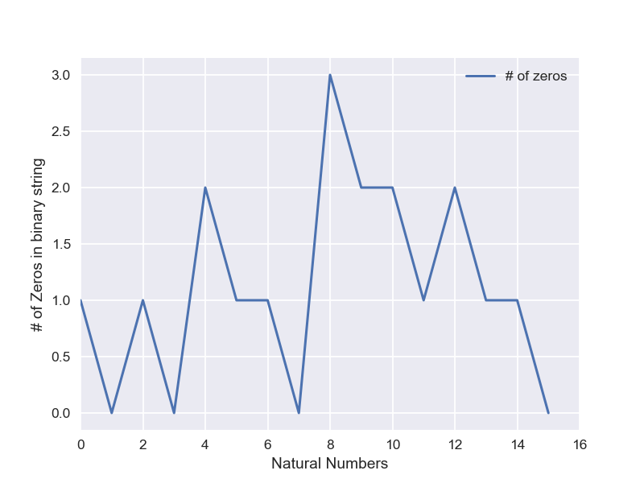

```python
sns.set()
plt.figure()
plt.plot(df['n'], df['zeros'], label='# of zeros');
plt.xlabel('Natural Numbers')
plt.ylabel('# of Zeros in binary string');
plt.xlim([0, end])
plt.legend();
```

##### Hint: adding ; at the end of plt.legend() will prevent output of something like '<matplotlib.legend.Legend at 0x2030abb5fd0>' below out plot

We could use plt.yticks() to set only integer values on y-axis because it does not make sense to say a number has 2.5 zeros, for example!

But, it's ok. Let's move ahead!

As we expected, 4 has 2 zeros, 6 has 1 zero etc.

## Heatmap

But this plot is not interesting to look at! Let's try out the seaborn heatmap and see what happens. Heatmap uses dataframe index for y-axis and columns on the x-axis.

So, let's set the index of dataframe to 'n' but be careful not to change the dataframe itself. It's for this heatmap. So, we do not use 'inplace' parameter.

##### Notice the ; at the end of 'sns.heatmap(df.set_index('n'))' to avoid unwanted output below the plot

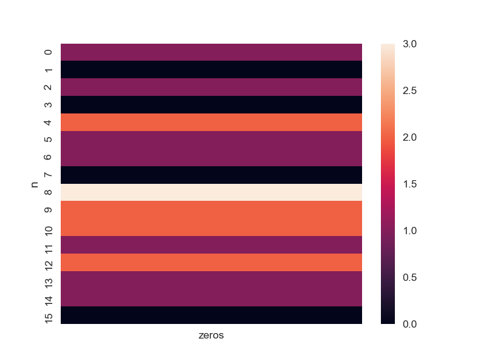

```python
plt.figure()
sns.heatmap(df.set_index('n'));
```

This looks better. May be a clothing brand can use this as their next design!

Let's try to increse our range now and see how the heatmap looks

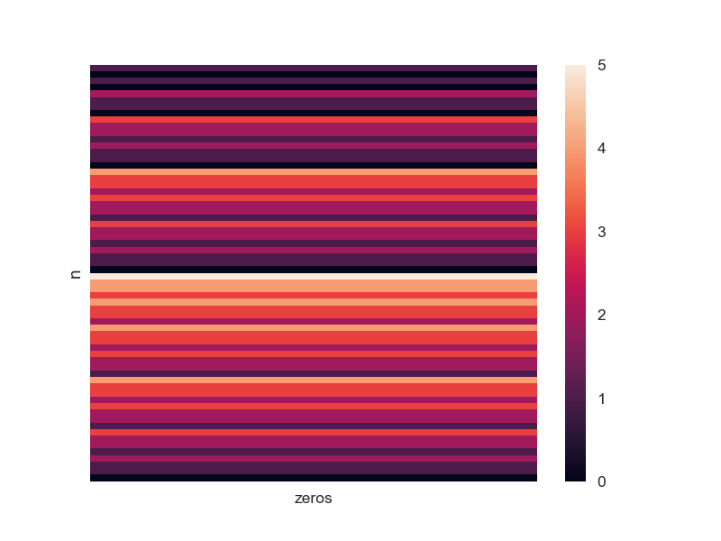

```python
end = 64
df = pd.DataFrame(np.arange(0, end, 1), columns=['n'])
df['zeros'] = list(map(zeros, df['n']))
plt.figure()
sns.heatmap(df.set_index('n'), yticklabels=False);
```

What's interesting is how very dark strip is followed by a relatively very bright strip. That's because, every $2^n - 1$ numebr does not have any zeros. Therefore, the darkest strip. Such a number is always followed by a $2^n$ which has just 1 one and remaining zeros. As the side color bar shows, more the zeros, brighter the strip becomes.

That was nice!

## Histogram

Let's try to plot 'how many numbers are there with specific number of zeros' kind of graph using a histogram. Range is set to 0 - 32.

We use plt.xticks() to avoid plotting numbers with decimal poitns on x-axis!

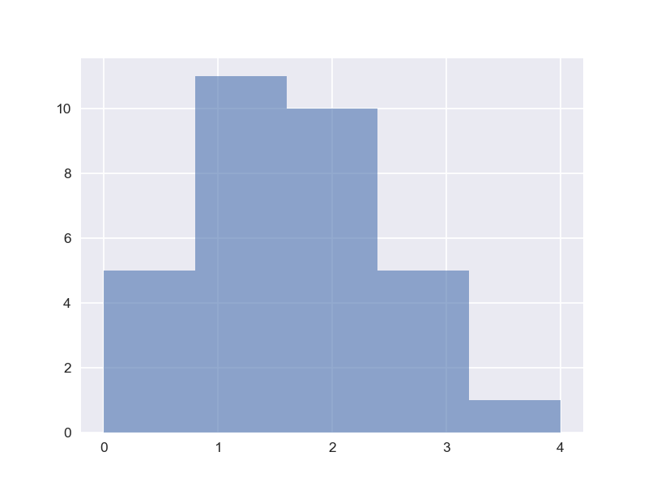

```python
end = 32
df = pd.DataFrame(np.arange(0, end, 1), columns=['n'])
df['zeros'] = list(map(zeros, df['n']))

plt.figure()
plt.hist(df['zeros'], bins=df['zeros'].max()+1, alpha=0.6);
plt.xticks(np.arange(0, df['zeros'].max()+1, 1));
```

Ok! What this plot tells us???

It tells us that, between 0 and 32,

- there are 5 numbers with no zeros (1, 3, 7, 15 and 31)
- 11 numbers with 1 zero (figure it out by yourself, I am tired!)
- 10 numbers with 2 zeros and so on...

Let's try this with a bigger number. Something like 1 million may be?

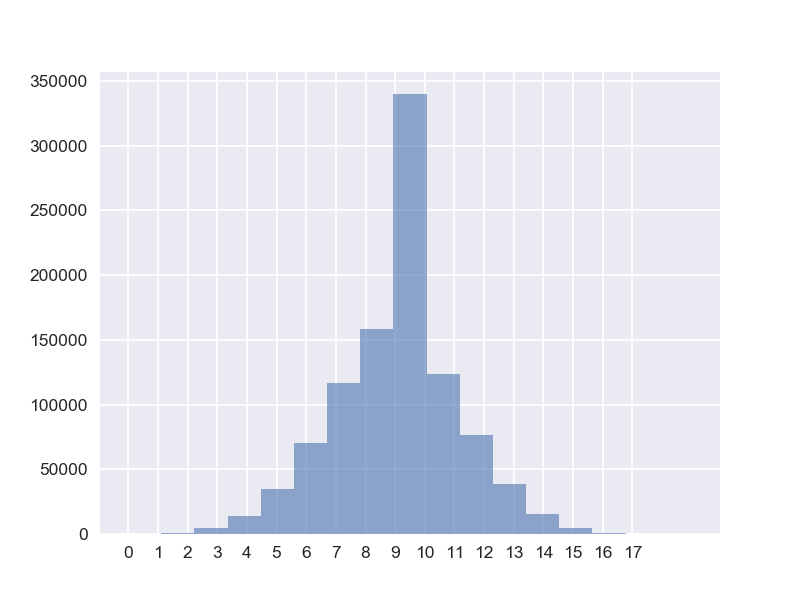

```python
end = 1000000
df = pd.DataFrame(np.arange(0, end, 1), columns=['n'])
df['zeros'] = list(map(zeros, df['n']))

plt.figure()
plt.hist(df['zeros'], bins=17, alpha=0.6);
plt.xticks(np.arange(0, 18, 1));
```

Wow!, There is a huge difference between number of numbers with 9 or 10 zeros and that with 8 zeros. But, total number of numbers with 8 zeros and 11 zeros is almost comes close that with 9 or 10 zeros.

At this moment, I am confused... arrrgghhhh!

## Combine 1s and 0s and see what happens

So, far we have not considered number of 1s at all. They must be feeling left alone! But, we expect that if we plot number of 1s and 0s, lines should kind of be on opposite sides all the time!

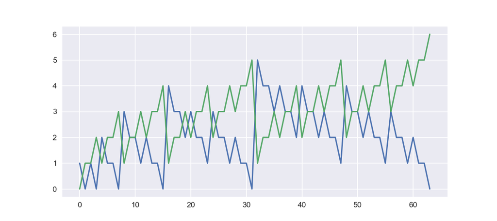

```python
end = 64
df = pd.DataFrame(np.arange(0, end, 1), columns=['n'])
df['zeros'] = list(map(zeros, df['n']))
df['ones'] = list(map(ones, df['n']))

plt.figure(figsize=[9, 4])
plt.plot(df['n'], df['zeros'], label='zeros');
plt.plot(df['n'], df['ones'], label='ones');
```

Bravo! That's a very interesting pattern, however.

What can we see here?

Look how the lines opens up in the end - linke a Demogorgon's mouth that's trying to swallow all the numbers that are in front of it!!!

Ok, I think we can stop here for the time being.

But, now another question is troubling me.

#### What is the probability of taking 10 numbers at random from numbers between 0 and 1 million that have same number of zeros and ones when converted to binary?!

#### And what happens if we plot those probabilities such as taking a number with no zeros, taking number with 1 zeros and so on?